# Práctica: Regresión Múltiple

Daniel Miranda

2025-06-11

# Equipo Docente

- Profesor: Daniel Miranda (danmiranda@uchile.cl)
- Apoyo Docente: Felipe Varas

# Introducción

Este documento resume las actividades para el análisis de regresión. Comienza con el análisis de confiabilidad de un indicador que luego se utiliza en un modelo de regresión.

## Instalar o instalar librerías útiles para la sesión

```r
#install.packages(c("splitstackshape","psych"))
library(readr)
library(splitstackshape)
library(psych)
library(summarytools)
library(skimr)
library(ggplot2)
library(dplyr)
library(kableExtra)
library(table1)
library(modest)
library(BSDA)
library(crosstable)
library(gmodels)
library(corrplot)
library(sjPlot)
library(stargazer)
library(rio)
library(performance)
library(see)
```

## Lectura de datos

Para nuestro análisis de datos se generó una base que evalúa multiples actitudes. Las c05_01 a la c05_08 se orientan a evaluar el grado de confianza en instituciones (por ejemplo: confianza en el Gobierno, Los Partidos Políticos, El Parlamento, etc.).

```r
base= rio::import("https://www.dropbox.com/scl/fi/wo7rvoz0lw9wkx65boen8/ELSOC_W01_subset.csv?rlkey=kox9y3ie7n61dj26hidg91o56&dl=1")
#names(base)
```

## Vista previa de la de datos

Los siguientes códigos permiten explorar los datos de manera general.

```r
# Vista previa de los datos
View(base)

# Mostrar los nombres de las variables contenidas en la base datos
names(base)
```

```
##  [1] "idencuesta" "c01"        "c02"        "c03"        "c04"
##  [6] "c05_01"     "c05_02"     "c05_03"     "c05_04"     "c05_05"
## [11] "c05_06"     "c05_07"     "c05_08"     "c06_01"     "c06_02"
## [16] "c06_03"     "c06_04"     "c06_05"     "c06_06"     "c11"
## [21] "c13"        "c14_01"     "c14_02"     "d05_02"     "d05_04"
## [26] "m0_sexo"    "m0_edad"    "m01"        "m35"
```

```r
# Muestra el número de filas y columnas (casos y variables)
dim(base)
```

```
## [1] 2927   29
```

```r
# Muestra los primeros 10 casos de la base para todas las variables
head(base, 10)
```

```
##    idencuesta c01 c02 c03 c04 c05_01 c05_02 c05_03 c05_04 c05_05 c05_06 c05_07
## 1     1101011   1   1   3   3      1      1      1      3      1      1      1
## 2     1101012   1   3   2   2      1      1      2      2      2      1      1
## 3     1101013   1   3   3   2      1      1      1      1      1      3      1
## 4     1101021   1   1   2   2      1      1      3      4      1      4      1
## 5     1101022   2   2   2   3      1      1      3      1      1      1      1
## 6     1101023   1   2   2   2      1      1      2      1      1      2      1
## 7     1101032   3   1   1   2      1      1      2      1      1      1      1
## 8     1101033   3   2   3   2      1      1      3      3      2      2      1
## 9     1101041   1   1   2   3      1      1      2      3      1      1      1
## 10    1101042   4   1   1   2      1      1      2      1      2      2      1
##    c05_08 c06_01 c06_02 c06_03 c06_04 c06_05 c06_06 c11 c13 c14_01 c14_02
## 1       1      1      1      1      4      2      1   1   1      2      2
## 2       1      1      1      1      3      2      4   2   1      1      1
## 3       1      1      1      1      5      4      2   1   1      1      1
```

[output cut: 18 more lines]

```r
# Muestra los primeros 10 casos de la base para una variable específica
head(base$c01, 10)
```

```
##  [1] 1 1 1 1 2 1 3 3 1 4
```

Otra forma de describir los datos rápidamente es usando la librería `summarytools`. Esta genera información para cada variable.

```r
print(summarytools::dfSummary(base, method = "render")) ## Descripción de la base de datos
```

Data Frame Summary  
base  
Dimensions: 2927 x 29  
Duplicates: 0

| No | Variable | Stats / Values | Freqs (% of Valid) | Graph | Valid | Missing |
| --- | --- | --- | --- | --- | --- | --- |
| 1 | idencuesta [integer] | Mean (sd) : 8993199 (6624147) min < med < max: 1101011 < 8110053 < 131230214 IQR (CV) : 7410944 (0.7) | 2927 distinct values | : : : : : | 2927 (100.0%) | 0 (0.0%) |
| 2 | c01 [integer] | Mean (sd) : 2 (1.1) min < med < max: 1 < 2 < 5 IQR (CV) : 2 (0.5) | 1 : 1228 (43.9%) 2 : 704 (25.2%) 3 : 591 (21.1%) 4 : 202 ( 7.2%) 5 : 73 ( 2.6%) | IIIIIIII IIIII IIII I | 2798 (95.6%) | 129 (4.4%) |
| 3 | c02 [integer] | Mean (sd) : 2 (0.4) min < med < max: 1 < 2 < 3 IQR (CV) : 0 (0.2) | 1 : 276 ( 9.6%) 2 : 2373 (82.4%) 3 : 232 ( 8.1%) | I IIIIIIIIIIIIIIII I | 2881 (98.4%) | 46 (1.6%) |
| 4 | c03 [integer] | Mean (sd) : 2 (0.5) min < med < max: 1 < 2 < 3 IQR (CV) : 0 (0.3) | 1 : 414 (14.3%) 2 : 2196 (75.9%) 3 : 284 ( 9.8%) | II IIIIIIIIIIIIIII I | 2894 (98.9%) | 33 (1.1%) |
| 5 | c04 [integer] | Mean (sd) : 1.5 (0.7) min < med < max: 1 < 1 < 3 IQR (CV) : 1 (0.5) | 1 : 1797 (62.6%) 2 : 723 (25.2%) 3 : 349 (12.2%) | IIIIIIIIIIII IIIII II | 2869 (98.0%) | 58 (2.0%) |
| 6 | c05_01 [integer] | Mean (sd) : 1.9 (1) min < med < max: 1 < 2 < 5 IQR (CV) : 2 (0.5) | 1 : 1363 (46.8%) 2 : 808 (27.7%) 3 : 554 (19.0%) 4 : 153 ( 5.2%) 5 : 37 ( 1.3%) | IIIIIIIII IIIII III I | 2915 (99.6%) | 12 (0.4%) |
| 7 | c05_02 [integer] | Mean (sd) : 1.4 (0.7) min < med < max: 1 < 1 < 5 IQR (CV) : 1 (0.5) | 1 : 2080 (71.6%) 2 : 557 (19.2%) 3 : 244 ( 8.4%) 4 : 20 ( 0.7%) 5 : 5 ( 0.2%) | IIIIIIIIIIIIII III I | 2906 (99.3%) | 21 (0.7%) |
| 8 | c05_03 [integer] | Mean (sd) : 3.1 (1.2) min < med < max: 1 < 3 < 5 IQR (CV) : 2 (0.4) | 1 : 376 (12.9%) 2 : 480 (16.4%) 3 : 883 (30.2%) 4 : 914 (31.3%) 5 : 270 ( 9.2%) | II III IIIIII IIIIII I | 2923 (99.9%) | 4 (0.1%) |
| 9 | c05_04 [integer] | Mean (sd) : 2.2 (1.2) min < med < max: 1 < 2 < 5 IQR (CV) : 2 (0.5) | 1 : 1043 (37.9%) 2 : 549 (20.0%) 3 : 722 (26.2%) 4 : 382 (13.9%) 5 : 55 ( 2.0%) | IIIIIII III IIIII II | 2751 (94.0%) | 176 (6.0%) |
| 10 | c05_05 [integer] | Mean (sd) : 1.9 (1) min < med < max: 1 < 2 < 5 IQR (CV) : 2 (0.5) | 1 : 1371 (47.2%) 2 : 679 (23.4%) 3 : 628 (21.6%) 4 : 183 ( 6.3%) 5 : 41 ( 1.4%) | IIIIIIIII IIII IIII I | 2902 (99.1%) | 25 (0.9%) |
| 11 | c05_06 [integer] | Mean (sd) : 2.1 (1) min < med < max: 1 < 2 < 5 IQR (CV) : 2 (0.5) | 1 : 1095 (38.1%) 2 : 716 (24.9%) 3 : 809 (28.1%) 4 : 218 ( 7.6%) 5 : 36 ( 1.3%) | IIIIIII IIII IIIII I | 2874 (98.2%) | 53 (1.8%) |
| 12 | c05_07 [integer] | Mean (sd) : 1.7 (0.9) min < med < max: 1 < 1 < 5 IQR (CV) : 1 (0.5) | 1 : 1662 (57.7%) 2 : 658 (22.8%) 3 : 457 (15.9%) 4 : 83 ( 2.9%) 5 : 20 ( 0.7%) | IIIIIIIIIII IIII III | 2880 (98.4%) | 47 (1.6%) |
| 13 | c05_08 [integer] | Mean (sd) : 2.1 (1.1) min < med < max: 1 < 2 < 5 IQR (CV) : 2 (0.5) | 1 : 1233 (42.4%) 2 : 626 (21.5%) 3 : 687 (23.6%) 4 : 275 ( 9.5%) 5 : 88 ( 3.0%) | IIIIIIII IIII IIII I | 2909 (99.4%) | 18 (0.6%) |
| 14 | c06_01 [integer] | Mean (sd) : 1.4 (0.8) min < med < max: 1 < 1 < 5 IQR (CV) : 1 (0.5) | 1 : 2057 (74.0%) 2 : 420 (15.1%) 3 : 245 ( 8.8%) 4 : 45 ( 1.6%) 5 : 13 ( 0.5%) | IIIIIIIIIIIIII III I | 2780 (95.0%) | 147 (5.0%) |
| 15 | c06_02 [integer] | Mean (sd) : 1.5 (0.8) min < med < max: 1 < 1 < 5 IQR (CV) : 1 (0.5) | 1 : 1915 (68.7%) 2 : 518 (18.6%) 3 : 295 (10.6%) 4 : 44 ( 1.6%) 5 : 15 ( 0.5%) | IIIIIIIIIIIII III II | 2787 (95.2%) | 140 (4.8%) |
| 16 | c06_03 [integer] | Mean (sd) : 1.5 (0.8) min < med < max: 1 < 1 < 5 IQR (CV) : 1 (0.6) | 1 : 1981 (70.9%) 2 : 461 (16.5%) 3 : 278 ( 9.9%) 4 : 53 ( 1.9%) 5 : 21 ( 0.8%) | IIIIIIIIIIIIII III I | 2794 (95.5%) | 133 (4.5%) |
| 17 | c06_04 [integer] | Mean (sd) : 2.7 (1.3) min < med < max: 1 < 3 < 5 IQR (CV) : 3 (0.5) | 1 : 747 (26.7%) 2 : 379 (13.5%) 3 : 803 (28.7%) 4 : 653 (23.3%) 5 : 217 ( 7.8%) | IIIII II IIIII IIII I | 2799 (95.6%) | 128 (4.4%) |
| 18 | c06_05 [integer] | Mean (sd) : 3 (1.3) min < med < max: 1 < 3 < 5 IQR (CV) : 2 (0.4) | 1 : 515 (18.7%) 2 : 332 (12.1%) 3 : 847 (30.8%) 4 : 747 (27.2%) 5 : 309 (11.2%) | III II IIIIII IIIII II | 2750 (94.0%) | 177 (6.0%) |
| 19 | c06_06 [integer] | Mean (sd) : 2.5 (1.2) min < med < max: 1 < 3 < 5 IQR (CV) : 2 (0.5) | 1 : 753 (27.5%) 2 : 523 (19.1%) 3 : 863 (31.6%) 4 : 466 (17.0%) 5 : 130 ( 4.8%) | IIIII III IIIIII III | 2735 (93.4%) | 192 (6.6%) |
| 20 | c11 [integer] | Mean (sd) : 1.7 (0.5) min < med < max: 1 < 2 < 3 IQR (CV) : 1 (0.3) | 1 : 920 (31.5%) 2 : 1976 (67.7%) 3 : 22 ( 0.8%) | IIIIII IIIIIIIIIIIII | 2918 (99.7%) | 9 (0.3%) |
| 21 | c13 [integer] | Mean (sd) : 1.7 (1.1) min < med < max: 1 < 1 < 5 IQR (CV) : 1 (0.6) | 1 : 1782 (61.2%) 2 : 509 (17.5%) 3 : 365 (12.5%) 4 : 178 ( 6.1%) 5 : 80 ( 2.7%) | IIIIIIIIIIII III II I | 2914 (99.6%) | 13 (0.4%) |
| 22 | c14_01 [integer] | Mean (sd) : 2.2 (1.2) min < med < max: 1 < 2 < 5 IQR (CV) : 2 (0.6) | 1 : 1177 (40.2%) 2 : 517 (17.7%) 3 : 788 (26.9%) 4 : 253 ( 8.6%) 5 : 190 ( 6.5%) | IIIIIIII III IIIII I I | 2925 (99.9%) | 2 (0.1%) |
| 23 | c14_02 [integer] | Mean (sd) : 3 (1.4) min < med < max: 1 < 3 < 5 IQR (CV) : 2 (0.5) | 1 : 661 (22.6%) 2 : 344 (11.8%) 3 : 841 (28.8%) 4 : 516 (17.6%) 5 : 563 (19.2%) | IIII II IIIII III III | 2925 (99.9%) | 2 (0.1%) |
| 24 | d05_02 [integer] | Mean (sd) : 4.2 (0.9) min < med < max: 1 < 4 < 5 IQR (CV) : 1 (0.2) | 1 : 59 ( 2.0%) 2 : 66 ( 2.3%) 3 : 250 ( 8.6%) 4 : 1271 (43.5%) 5 : 1277 (43.7%) |  | 2923 (99.9%) | 4 (0.1%) |
| 25 | d05_04 [integer] | Mean (sd) : 4 (1.1) min < med < max: 1 < 4 < 5 IQR (CV) : 2 (0.3) | 1 : 114 ( 3.9%) 2 : 168 ( 5.8%) 3 : 455 (15.6%) 4 : 1056 (36.3%) 5 : 1117 (38.4%) | I III IIIIIII IIIIIII | 2910 (99.4%) | 17 (0.6%) |
| 26 | m0_sexo [integer] | Min : 1 Mean : 1.6 Max : 2 | 1 : 1163 (39.7%) 2 : 1764 (60.3%) | IIIIIII IIIIIIIIIIII | 2927 (100.0%) | 0 (0.0%) |
| 27 | m0_edad [integer] | Mean (sd) : 46.1 (15.3) min < med < max: 18 < 46 < 88 IQR (CV) : 25 (0.3) | 63 distinct values | . . . : : . : : : : : . : : : : : : : : : : : : : : : : : : : : : : : : . | 2927 (100.0%) | 0 (0.0%) |
| 28 | m01 [integer] | Mean (sd) : 5.3 (2.2) min < med < max: 1 < 5 < 10 IQR (CV) : 3 (0.4) | 1 : 37 ( 1.3%) 2 : 322 (11.0%) 3 : 297 (10.2%) 4 : 394 (13.5%) 5 : 857 (29.3%) 6 : 102 ( 3.5%) 7 : 381 (13.0%) 8 : 186 ( 6.4%) 9 : 303 (10.4%) 10 : 46 ( 1.6%) | II II II IIIII | 2925 (99.9%) | 2 (0.1%) |
| 29 | m35 [integer] | Mean (sd) : 2.1 (1.1) min < med < max: 1 < 2 < 6 IQR (CV) : 2 (0.5) | 1 : 1087 (37.5%) 2 : 762 (26.3%) 3 : 788 (27.2%) 4 : 187 ( 6.5%) 5 : 47 ( 1.6%) 6 : 24 ( 0.8%) | IIIIIII IIIII IIIII I | 2895 (98.9%) | 32 (1.1%) |

# Confiabilidad como consistencia interna

La confiabilidad/precisión apunta al nivel de incertidumbre que está asociado con las mediciones que son generadas por un instrumento de medición.

Si bien es solo una de muchas formas de calcular un coeficiente de confiabilidad el alfa de Cronbach es muy usado en la psicología. Este es probablemente el indicador estadístico más solicitado, más reportado en psicología.

Se lo considera una medida de consistencia interna.

- Aumenta cuando la inter-correlación entre los ítems aumenta. Por lo tanto aumenta cuando todos los ítems miden el mismo constructo.
- Indirectamente indica el grado en que un conjunto de ítems mide un constructo unidimensional simple.

Guías de interpretación:

- $≥ .90 : Excelente$
- $0.7 a 0.9: Bueno$
- $0.6 a 0.7: Aceptable$
- $0.5 a 0.6: Pobre$
- $< 0.5: Muy Pobre$

### Descripción de la asociación entre indicadores de Confianza

Matriz de correlaciones

```r
## Seleccionamos las variables a analizar
conf=base%>%
  dplyr::select(c05_01, c05_02, c05_03, c05_04, c05_05, c05_06, c05_07, c05_08)

tab_corr(conf)
```

|  | c05_01 | c05_02 | c05_03 | c05_04 | c05_05 | c05_06 | c05_07 | c05_08 |
| --- | --- | --- | --- | --- | --- | --- | --- | --- |
| c05_01 |  | 0.489*** | 0.293*** | 0.269*** | 0.375*** | 0.272*** | 0.470*** | 0.633*** |
| c05_02 | 0.489*** |  | 0.206*** | 0.278*** | 0.371*** | 0.276*** | 0.474*** | 0.364*** |
| c05_03 | 0.293*** | 0.206*** |  | 0.286*** | 0.306*** | 0.327*** | 0.240*** | 0.267*** |
| c05_04 | 0.269*** | 0.278*** | 0.286*** |  | 0.334*** | 0.312*** | 0.319*** | 0.297*** |
| c05_05 | 0.375*** | 0.371*** | 0.306*** | 0.334*** |  | 0.416*** | 0.532*** | 0.380*** |
| c05_06 | 0.272*** | 0.276*** | 0.327*** | 0.312*** | 0.416*** |  | 0.451*** | 0.264*** |
| c05_07 | 0.470*** | 0.474*** | 0.240*** | 0.319*** | 0.532*** | 0.451*** |  | 0.482*** |
| c05_08 | 0.633*** | 0.364*** | 0.267*** | 0.297*** | 0.380*** | 0.264*** | 0.482*** |  |
| Computed correlation used pearson-method with listwise-deletion. |  |  |  |  |  |  |  |  |

Gráfico de correlaciones

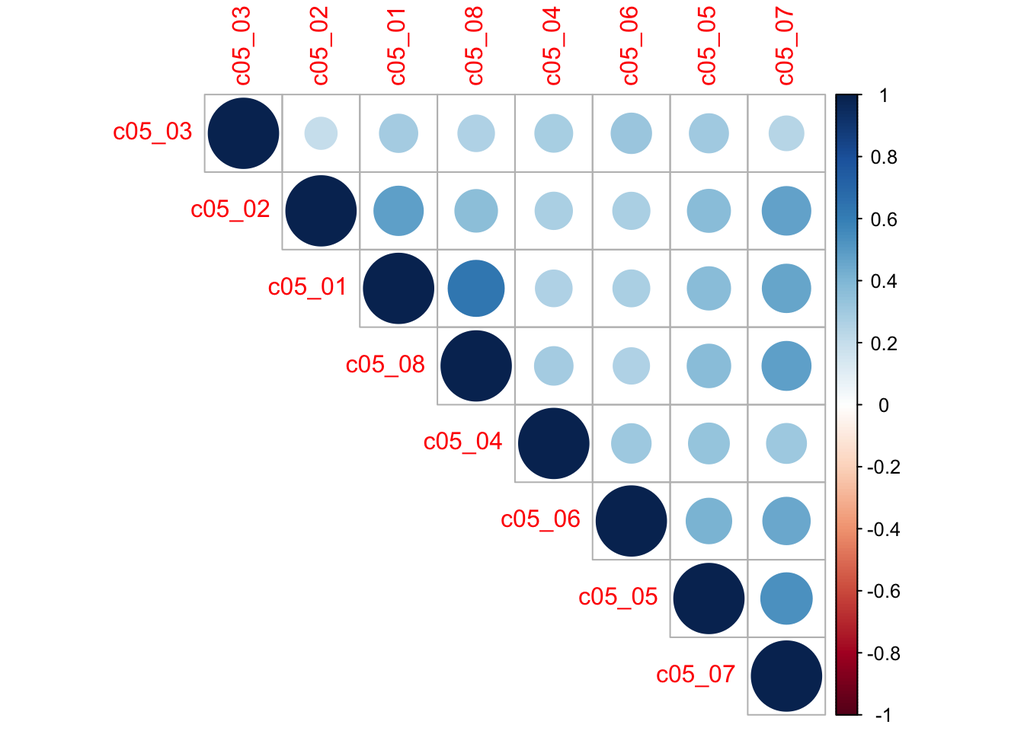

### Estimación de Alfa de Cronbach.

```r
tab_itemscale(conf)
```

Component 1

| Row | Missings | Mean | SD | Skew | Item Difficulty | Item Discrimination | α if deleted |  |
| --- | --- | --- | --- | --- | --- | --- | --- | --- |
| c05_01 | 0.41 % | 1.87 | 0.98 | 0.93 | 0.37 | 0.60 | 0.77 |  |
| c05_02 | 0.72 % | 1.39 | 0.68 | 1.75 | 0.28 | 0.52 | 0.79 |  |
| c05_03 | 0.14 % | 3.08 | 1.16 | -0.29 | 0.62 | 0.41 | 0.80 |  |
| c05_04 | 6.01 % | 2.22 | 1.15 | 0.42 | 0.44 | 0.44 | 0.80 |  |
| c05_05 | 0.85 % | 1.91 | 1.03 | 0.83 | 0.38 | 0.58 | 0.78 |  |
| c05_06 | 1.81 % | 2.09 | 1.03 | 0.5 | 0.42 | 0.49 | 0.79 |  |
| c05_07 | 1.61 % | 1.66 | 0.89 | 1.2 | 0.33 | 0.64 | 0.77 |  |
| c05_08 | 0.61 % | 2.09 | 1.14 | 0.69 | 0.42 | 0.57 | 0.78 |  |
| Mean inter-item-correlation=0.356 · Cronbach’s α=0.806 |  |  |  |  |  |  |  |  |

¿Qué te muestra esta tabla?

- Puedes ver qué ítemes incluiste a través de *Row*
- Puedes ver con qué frecuencia falta casos a través de *Missing*
- Puede ver estadísticas descriptivas de los ítemes mediante *Mean, SD y Skew*
- Puede ver cuán útiles son los ítemes para medir el concepto latente de Confianza en Instituciones a través de la dificultad del ítem, la discriminación del íteme y *alpha de Cronbach* si se elimina el ítem.

### Conclusión acerca de la escala de Confianza.

```r
base <- base %>%
  dplyr::mutate(conf_inst= (c05_01 + c05_02 + c05_03 + c05_04 + c05_05  + c05_06 + c05_07 + c05_08)/8)

## Revisar la variable agregada
#print(summarytools::dfSummary(base, method = "render")) ## Descripción de la base de datos
names(base)
```

```
##  [1] "idencuesta" "c01"        "c02"        "c03"        "c04"
##  [6] "c05_01"     "c05_02"     "c05_03"     "c05_04"     "c05_05"
## [11] "c05_06"     "c05_07"     "c05_08"     "c06_01"     "c06_02"
## [16] "c06_03"     "c06_04"     "c06_05"     "c06_06"     "c11"
## [21] "c13"        "c14_01"     "c14_02"     "d05_02"     "d05_04"
## [26] "m0_sexo"    "m0_edad"    "m01"        "m35"        "conf_inst"
```

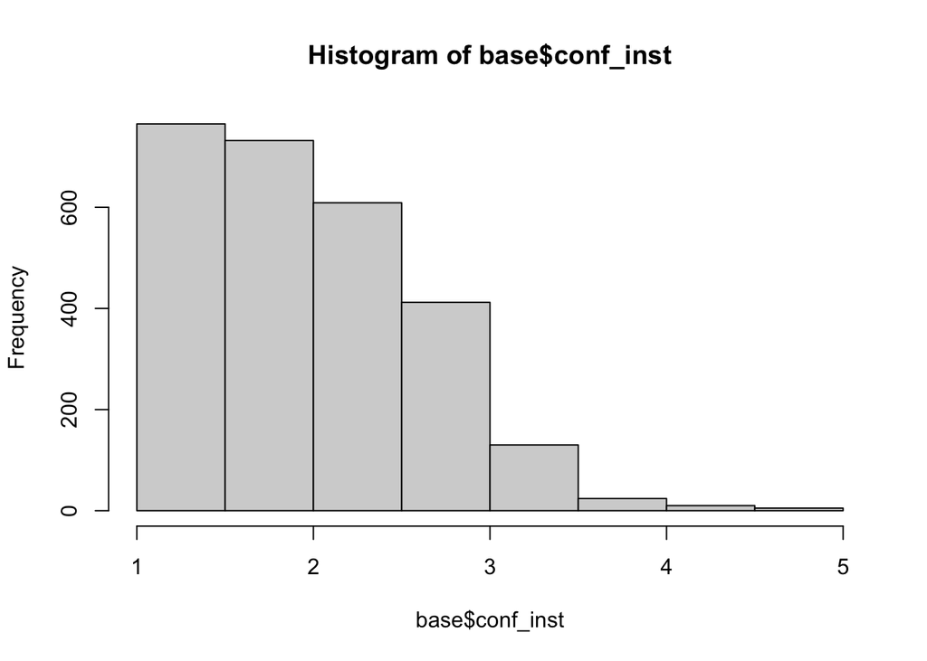

```r
hist(base$conf_inst)
```

```r
skim(base$conf_inst)
```

Data summary

| Name | base$conf_inst |
| --- | --- |
| Number of rows | 2927 |
| Number of columns | 1 |
| _______________________ |  |
| Column type frequency: |  |
| numeric | 1 |
| ________________________ |  |
| Group variables | None |

**Variable type: numeric**

| skim_variable | n_missing | complete_rate | mean | sd | p0 | p25 | p50 | p75 | p100 | hist |
| --- | --- | --- | --- | --- | --- | --- | --- | --- | --- | --- |
| data | 240 | 0.92 | 2.02 | 0.66 | 1 | 1.5 | 2 | 2.5 | 5 | ▇▇▃▁▁ |

# Regresión

La Regresión Lineal sirve para predecir una variable, sabiendo cómo se comporta la otra.

Esto lo hace a partir de la recta de regresión, en torno a la cual, se ajustan los datos con las distancias cuadráticas mínimas.

Esta recta (línea) de regresión representa la mejor solución estimada para predecir los datos (variable dependiente) a partir de las variables independiente: línea o recta con el mejor ajuste.

Donde: - $𝑌$ es la variable dependiente

- $𝑥$ son las variables independientes
- $\epsilon_̇i$ es el error asociado a la estimación de$Y$ (error de estimación individual)
- El parámetro $\alpha$ (también conocimcido como $\beta_0$) es el intercepto (Valor de $Y$ cuando los $X = 0$).
- $\beta_1$ refiere a la pendiente estimada. Que indican cuanto cambia, en promedio, $Y$ ante el cambio de una unidad de $X$ (considerando todas las otras $X$ del modelo como constantes, *Seteris Paribus*, cuando hay otros predictores).

*Seteris Paribus* se usa como expresión cuando se interpretan las pendientes en un modelo de regresión múltiple. Significa, mantendiendo el resto constante o controlando por las otras variables.

En este ejemplo, usaremos en indicador de confianza en instituciones recién creado, como variable dependiente. Para explicar los niveles de confianza, nos preguntamos: ¿en qué medida la confianza en instituciones es explicada por el grado de interés en la política, los niveles de conversación sobre política y por el nivel educacional.

Para responder esta pregunta se realiza un análisis de regresión, utilizando las siguientes variables independientes disponibles:

- Interés en política (c13): varía de 1 a 5, donde 5 indica mayor interés.
- Conversación sobre política (c14_01): varía de 1 a 5, donde 5 indica mayor frecuencia de conversación.
- Nivel educacional (m01): varía de 1 a 10, donde mayores puntajes indican mayor nivel educacional.

### Matriz de correlaciones

El análisis de correlaciones permite explorar la asocación entre variables. En este caso, se estima una matriz de correlaciones que muestras las asociaciones lineales entre las las variables de interés.

```r
#names(base)

# Preparar la base: crear nombres y guardar variables de interés
reg=base%>%
  mutate(Interés= c13) %>%
  mutate(Conversación= c14_01) %>%
  mutate(Educación= m01) %>%
  mutate(Confianza= conf_inst) %>%
  dplyr::select(Confianza, Interés, Conversación, Educación)


skim(reg)
```

Data summary

| Name | reg |
| --- | --- |
| Number of rows | 2927 |
| Number of columns | 4 |
| _______________________ |  |
| Column type frequency: |  |
| numeric | 4 |
| ________________________ |  |
| Group variables | None |

**Variable type: numeric**

| skim_variable | n_missing | complete_rate | mean | sd | p0 | p25 | p50 | p75 | p100 | hist |
| --- | --- | --- | --- | --- | --- | --- | --- | --- | --- | --- |
| Confianza | 240 | 0.92 | 2.02 | 0.66 | 1 | 1.5 | 2 | 2.5 | 5 | ▇▇▃▁▁ |
| Interés | 13 | 1.00 | 1.72 | 1.07 | 1 | 1.0 | 1 | 2.0 | 5 | ▇▂▂▁▁ |
| Conversación | 2 | 1.00 | 2.23 | 1.24 | 1 | 1.0 | 2 | 3.0 | 5 | ▇▃▆▂▁ |
| Educación | 2 | 1.00 | 5.26 | 2.20 | 1 | 4.0 | 5 | 7.0 | 10 | ▃▆▇▅▃ |

```r
# Matriz de correlaciones
tab_corr(reg)
```

|  | Confianza | Interés | Conversación | Educación |
| --- | --- | --- | --- | --- |
| Confianza |  | 0.305*** | 0.169*** | 0.139*** |
| Interés | 0.305*** |  | 0.583*** | 0.334*** |
| Conversación | 0.169*** | 0.583*** |  | 0.333*** |
| Educación | 0.139*** | 0.334*** | 0.333*** |  |
| Computed correlation used pearson-method with listwise-deletion. |  |  |  |  |

Se puede ver que la correlación entre interés político con confianza es positiva (r=0.305, p<0.01), mediana y estadíticamente significativa. Así mismo, las correlaciones de conversación política (r= 0.169, p<0.01) y Educación (r= 0.139, p<0.01) con confianza política son positivas, pequeñas y estadísticamente significativas.

### Regresión simple

Primero, estimaremos un modelo de regresión utilizando la variable de Interés político para predecir Confianza en Instituciones.

```r
simple= lm(Confianza ~ Interés, data=reg)
summary(simple)
```

Call: lm(formula = Confianza ~ Interés, data = reg)

Residuals: Min 1Q Median 3Q Max -1.62664 -0.51197 -0.01197 0.42811 3.11303

Coefficients: Estimate Std. Error t value Pr(>|t|)  
(Intercept) 1.70205 0.02300 74.01 <2e-16 *Interés 0.18492 0.01119 16.53 <2e-16* — Signif. codes: 0 ‘**’ 0.001 ’**’ 0.01 ’’ 0.05 ‘.’ 0.1 ’ ’ 1

Residual standard error: 0.631 on 2679 degrees of freedom (246 observations deleted due to missingness) Multiple R-squared: 0.09254, Adjusted R-squared: 0.0922 F-statistic: 273.2 on 1 and 2679 DF, p-value: < 2.2e-16

```r
stargazer(simple, type="latex")
```

[output not shown]

#### Interpretación del ajuste del modelo

- El ajuste del modelo se analiza a partir del test de ANOVA del modelo. El resultado muestra que el modelo explica mejor que los residuos ($F_{(1,2679)}= 273.2; p<0.001$). Por lo tanto, podemos interpretar los coeficientes.
- El coeficiente de determinación ($R^2$) y el coeficiente de determinación ajustado ($R^2 ajustado$) muestran que el modelo explica un 9,2% y un 9,2% de la varianza, respectivamente.

#### Interpretación de los coeficientes

- El intercepto $\alpha$ ó $\beta_0$ muestra que, cuando el interés en política es 0, la confianza política esperada es de $\beta_0 = 1.70$.
- La pendiente $\beta_1$ muestra que, por cada punto que aumenta el interés en política, la confianza política aumenta en $0.184$ ($p<0.01$) puntos. Este efecto es estadísticamente significativo.
- Usando la ecuación de la recta podemos predecir valores esperados. Por ejemplo, ¿qué niveles de confianza política tendría una persona con el mayor nivel de interés en política (es decir, $x=5$ puntos de interés).
  - $\hat{Y}= \beta_0 + \beta_1 x$
  - $\hat{Y}= 1.70 + (0.184*5)$
  - $\hat{Y}= 2.62$

Entonces, el nivel de confianza política esperada para una persona con el mayor nivel de interés en política ($x=5$) es de 2.62 puntos.

### Regresión múltiple

Ahora, estimaremos un modelo de regresión múltiple utilizando las tres variable independientes para predecir Confianza en Instituciones.

```r
multiple= lm(Confianza ~ Interés + Conversación + Educación, data=reg)
#summary(multiple)
stargazer(multiple, type="text")
```

=============================================== Dependent variable:  
————————— Confianza  
———————————————– Interés 0.184***  
(0.014)

Conversación -0.012  
(0.012)

Educación 0.014**  
(0.006)

Constant 1.659***  
(0.035)

Observations 2,677  
R2 0.095  
Adjusted R2 0.094  
Residual Std. Error 0.631 (df = 2673)  
F Statistic 93.196*** (df = 3; 2673)  
=============================================== Note: *p<0.1; **p<0.05;*** p<0.01

#### Interpretación de los coeficientes

Entonces, el nivel de confianza política esperada para una persona con el mayor nivel de interés en política ($x_1=5$) y el mayor nivel educacional ($x_3=10$) es de 2.72. puntos.

### Chequeo de supuestos

```r
performance::check_model(simple)

performance::check_model(multiple)
```

[output not shown]

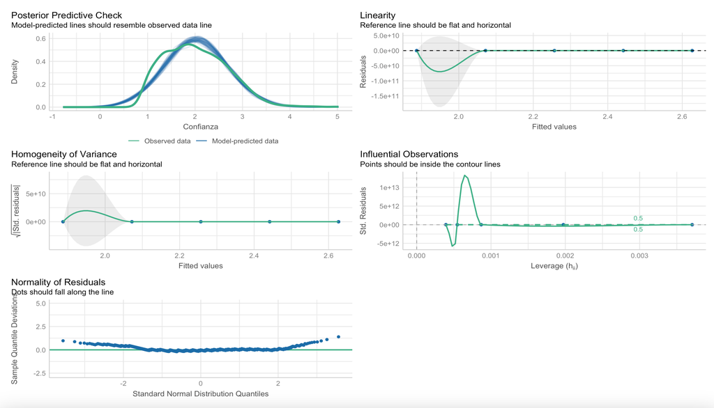